# index

Maksym Shulika

2026-05-08

# Uvod: Co su to - parne funkcie?

Chcel by som prejst po takej teme,ako parne funkcie. Co sa oni z seba predstavuju? Preco sa vobec zaoberat’ parnymi funkciami? Na prvy pohlad sa mozu zdat len ako matematicka zaujimavost’ – funkcie symetricke podla zvislej osi. V skutocnosti vsak zohravaju dolezitu ulohu vo fyzike, statistike, spracovani signalov aj v samotnej matematike.

Parne funkcie sa objavuju naprklad pri harmonickom kmitani, rozdeleni rychlosti molekul ci difrakcii svetla. Vdaka svojej symetrii zaroven vyrazne zjednodusuju vypocty integralov, derivacii a rozvojov do radov.

Cielom tohto projektu je predstavit ich zakladne vlastnosti, uviest konkretne priklady a ukazat ich prakticke vyuzitie. V dalsich kapitolach sa zameriame na definiciu, priklady, spravanie pri integracii a derivacii, Fourierove rady a fyzikalne aplikacie.

## 1 kapitola. Vstup do temy: “Parna funkcia a ich vlastnosti”

*Parne funkcie* - to su funkcie,ktore symmetricke cez nulu.

**Plati pre nu podmienka:**
$$f(−x)=f(x)$$

To znamená, ze graf funkcie je *“odzrkadleny”* od osi Y.

Pridavam niekolko prikladov parnych funkcii:

## Tabulka parnych funkcii:

```r
funkcii <- data.frame(
  number = 1:9,
  func = c("$x^2$", "$x^4$", "$x^{100}$", "$$ \\mid x \\mid $$", "$\\cos(x)$",
              "$\\frac{1}{x^2}$", "$x^4 - 5x^2 + 1$", "$e^{x^2}$", "$konstanta$")
)

kable(funkcii, caption = "Tabulka parnych funkcii",
      booktabs = TRUE, align = "c")
```

Tabulka parnych funkcii

| number | func |
| --- | --- |
| 1 | $x^2$ |
| 2 | $x^4$ |
| 3 | $x^{100}$ |
| 4 | $$\mid x \mid$$ |
| 5 | $\cos(x)$ |
| 6 | $\frac{1}{x^2}$ |
| 7 | $x^4 - 5x^2 + 1$ |
| 8 | $e^{x^2}$ |
| 9 | $konstanta$ |

Mozme pozriet trochu hlbshie na jednu z tychto funkcii,napriklad,$cos(x)$;

## Graf cos(x)

$$y = cos(x)$$
;

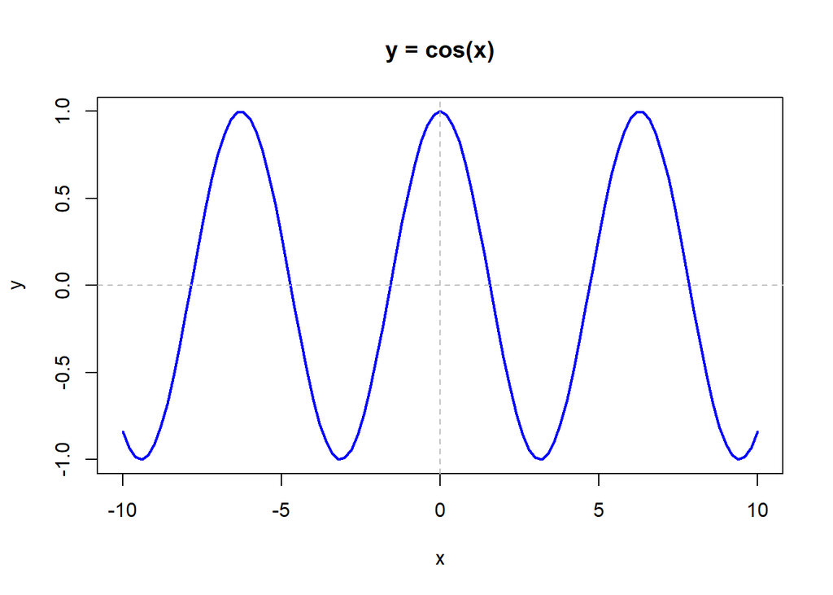

```r
curve(cos(x), from = -10, to = 10,
      col = "blue", lwd = 2,
      main = "y = cos(x)",
      xlab = "x", ylab = "y")
abline(h = 0, v = 0, col = "gray", lty = 2)
```

Ako mozeme vsimnut,ona je symetricka na os Y,akoze *odzrkadlena* od nu.

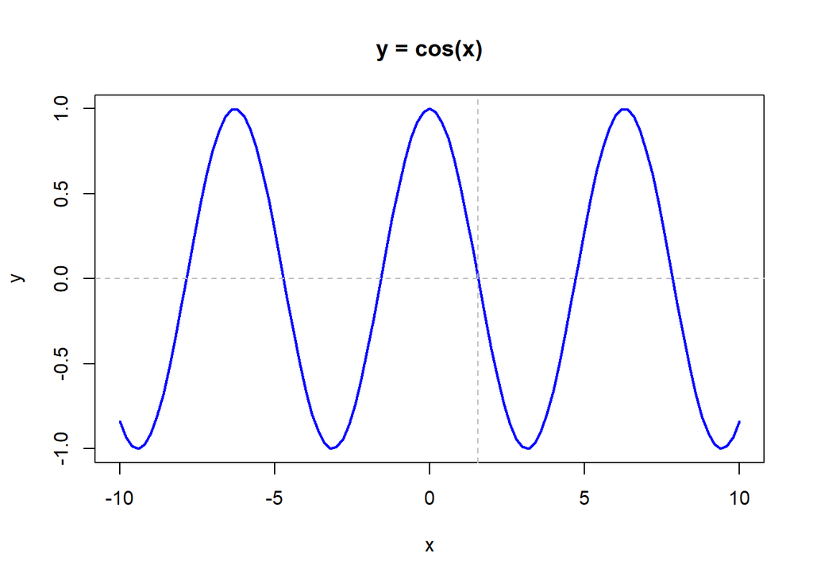

```r
curve(cos(x), from = -10, to = 10,
      col = "blue", lwd = 2,
      main = "y = cos(x)",
      xlab = "x", ylab = "y")
abline(h = 0, v = pi/2, col = "gray", lty = 2)
```

# 2. kapitola - Zauimave fakty.

## Vlastnost’ #1

Jedna z zauimavych vlastnosti parnych funkcii :

*Ak integrujeme funkciu cez symetricky interval*: $[-1,1]$ *alebo* $[-10,10]$ *(integral ot* $-1$ *do* $1$ *ot funkcii* $1/(x^2)$)*,tak vysledok bude taky isty,ako keby sme urobili sumu* $2$ *integralov na intervale* $[0,1]$ *alebo* $[0,10]$.

## **Riešenie:**

$$\int_{-1}^{1} \frac{1}{x^2} \, dx = 2
\int_{0}^{1} \frac{1}{x^2} \, dx$$

$$= 2 \left[ -\frac{1}{x} \right]_{0}^{1}
= 2 \left( -\frac{1}{1} + \lim_{x \to 0^+} \frac{1}{x} \right) =
\infty$$

**Pozor:** Integrál diverguje (nie je konecny), ale vzt’ah $2\int_0^1$ stale plati!

## Vlastnost’ #2

**Este** jedna zauimava vlastnost: derivacia parnej funkcie **vzdy** bude neparna funkcia!

$$f(x) = x^2 \quad \text{(parna)}$$

$$f'(x) = 2x \quad \text{(neparna,
lebo } 2(-x) = -2x\text{)}$$

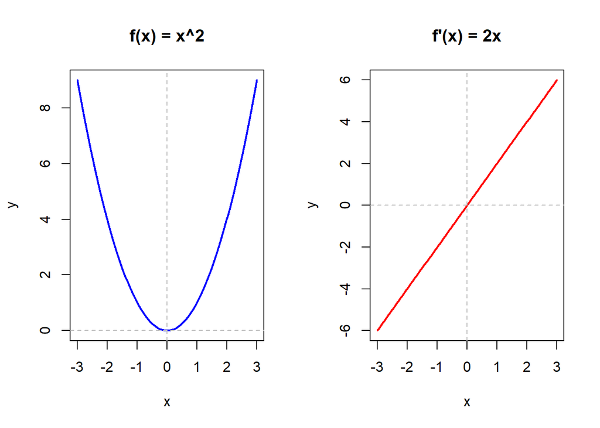

```r
par(mfrow = c(1, 2))

curve(x^2, from = -3, to = 3, col = "blue", lwd = 2,
      main = "f(x) = x^2", xlab = "x", ylab = "y")
abline(h = 0, v = 0, col = "gray", lty = 2)

curve(2*x, from = -3, to = 3, col = "red", lwd = 2,
      main = "f'(x) = 2x", xlab = "x", ylab = "y")
abline(h = 0, v = 0, col = "gray", lty = 2)
```

```r
par(mfrow = c(1, 1))
```